# Risk Factor Analysis

## Outcome Variable

**Outcome Variable:** y_rate_haz

## Predictor Variables

**Intervention Variable:** perdiar6

**Adjustment Set:**

unadjusted

## Stratifying Variables

The analysis was stratified on these variable(s):

- agecat
- studyid
- country

## Data Summary

| agecat | studyid | country | perdiar6 | n_cell | n |
| --- | --- | --- | --- | --- | --- |
| 0-3 months | ki0047075b-MAL-ED | BANGLADESH | Q1 | 243 | 244 |
| 0-3 months | ki0047075b-MAL-ED | BANGLADESH | Q2 | 1 | 244 |
| 0-3 months | ki1017093-NIH-Birth | BANGLADESH | Q1 | 554 | 566 |
| 0-3 months | ki1017093-NIH-Birth | BANGLADESH | Q2 | 12 | 566 |
| 0-3 months | ki1017093b-PROVIDE | BANGLADESH | Q1 | 629 | 634 |
| 0-3 months | ki1017093b-PROVIDE | BANGLADESH | Q2 | 5 | 634 |
| 0-3 months | ki1017093c-NIH-Crypto | BANGLADESH | Q1 | 716 | 720 |
| 0-3 months | ki1017093c-NIH-Crypto | BANGLADESH | Q2 | 4 | 720 |
| 0-3 months | ki1114097-CMIN | BANGLADESH | Q1 | 41 | 43 |
| 0-3 months | ki1114097-CMIN | BANGLADESH | Q2 | 2 | 43 |
| 0-3 months | ki0047075b-MAL-ED | BRAZIL | Q1 | 180 | 180 |
| 0-3 months | ki1114097-CMIN | BRAZIL | Q1 | 81 | 81 |
| 0-3 months | ki1114097-CMIN | GUINEA-BISSAU | Q1 | 21 | 21 |
| 0-3 months | ki0047075b-MAL-ED | INDIA | Q1 | 200 | 201 |
| 0-3 months | ki0047075b-MAL-ED | INDIA | Q2 | 1 | 201 |
| 0-3 months | ki0047075b-MAL-ED | NEPAL | Q1 | 172 | 175 |
| 0-3 months | ki0047075b-MAL-ED | NEPAL | Q2 | 3 | 175 |
| 0-3 months | ki1000109-ResPak | PAKISTAN | Q1 | 73 | 78 |
| 0-3 months | ki1000109-ResPak | PAKISTAN | Q2 | 5 | 78 |
| 0-3 months | ki0047075b-MAL-ED | PERU | Q1 | 266 | 271 |
| 0-3 months | ki0047075b-MAL-ED | PERU | Q2 | 5 | 271 |
| 0-3 months | ki1114097-CMIN | PERU | Q1 | 88 | 93 |
| 0-3 months | ki1114097-CMIN | PERU | Q2 | 5 | 93 |
| 0-3 months | ki1114097-CONTENT | PERU | Q1 | 29 | 29 |
| 0-3 months | ki0047075b-MAL-ED | SOUTH AFRICA | Q1 | 229 | 229 |
| 0-3 months | ki0047075b-MAL-ED | TANZANIA, UNITED REPUBLIC OF | Q1 | 229 | 229 |
| 3-6 months | ki0047075b-MAL-ED | BANGLADESH | Q1 | 230 | 231 |
| 3-6 months | ki0047075b-MAL-ED | BANGLADESH | Q2 | 1 | 231 |
| 3-6 months | ki1017093-NIH-Birth | BANGLADESH | Q1 | 516 | 523 |
| 3-6 months | ki1017093-NIH-Birth | BANGLADESH | Q2 | 7 | 523 |

[output cut: 83 more lines]

The following strata were considered:

- agecat: 0-3 months, studyid: ki0047075b-MAL-ED, country: BANGLADESH
- agecat: 0-3 months, studyid: ki0047075b-MAL-ED, country: BRAZIL
- agecat: 0-3 months, studyid: ki0047075b-MAL-ED, country: INDIA
- agecat: 0-3 months, studyid: ki0047075b-MAL-ED, country: NEPAL
- agecat: 0-3 months, studyid: ki0047075b-MAL-ED, country: PERU
- agecat: 0-3 months, studyid: ki0047075b-MAL-ED, country: SOUTH AFRICA
- agecat: 0-3 months, studyid: ki0047075b-MAL-ED, country: TANZANIA, UNITED REPUBLIC OF
- agecat: 0-3 months, studyid: ki1000109-ResPak, country: PAKISTAN
- agecat: 0-3 months, studyid: ki1017093-NIH-Birth, country: BANGLADESH
- agecat: 0-3 months, studyid: ki1017093b-PROVIDE, country: BANGLADESH
- agecat: 0-3 months, studyid: ki1017093c-NIH-Crypto, country: BANGLADESH
- agecat: 0-3 months, studyid: ki1114097-CMIN, country: BANGLADESH
- agecat: 0-3 months, studyid: ki1114097-CMIN, country: BRAZIL
- agecat: 0-3 months, studyid: ki1114097-CMIN, country: GUINEA-BISSAU
- agecat: 0-3 months, studyid: ki1114097-CMIN, country: PERU
- agecat: 0-3 months, studyid: ki1114097-CONTENT, country: PERU
- agecat: 12-24 months, studyid: ki0047075b-MAL-ED, country: BANGLADESH
- agecat: 12-24 months, studyid: ki0047075b-MAL-ED, country: BRAZIL
- agecat: 12-24 months, studyid: ki0047075b-MAL-ED, country: INDIA
- agecat: 12-24 months, studyid: ki0047075b-MAL-ED, country: NEPAL
- agecat: 12-24 months, studyid: ki0047075b-MAL-ED, country: PERU
- agecat: 12-24 months, studyid: ki0047075b-MAL-ED, country: SOUTH AFRICA
- agecat: 12-24 months, studyid: ki0047075b-MAL-ED, country: TANZANIA, UNITED REPUBLIC OF
- agecat: 12-24 months, studyid: ki1017093-NIH-Birth, country: BANGLADESH
- agecat: 12-24 months, studyid: ki1017093b-PROVIDE, country: BANGLADESH
- agecat: 12-24 months, studyid: ki1017093c-NIH-Crypto, country: BANGLADESH
- agecat: 12-24 months, studyid: ki1114097-CMIN, country: BANGLADESH
- agecat: 12-24 months, studyid: ki1114097-CMIN, country: GUINEA-BISSAU
- agecat: 12-24 months, studyid: ki1114097-CMIN, country: PERU
- agecat: 12-24 months, studyid: ki1114097-CONTENT, country: PERU
- agecat: 3-6 months, studyid: ki0047075b-MAL-ED, country: BANGLADESH
- agecat: 3-6 months, studyid: ki0047075b-MAL-ED, country: BRAZIL
- agecat: 3-6 months, studyid: ki0047075b-MAL-ED, country: INDIA
- agecat: 3-6 months, studyid: ki0047075b-MAL-ED, country: NEPAL
- agecat: 3-6 months, studyid: ki0047075b-MAL-ED, country: PERU
- agecat: 3-6 months, studyid: ki0047075b-MAL-ED, country: SOUTH AFRICA
- agecat: 3-6 months, studyid: ki0047075b-MAL-ED, country: TANZANIA, UNITED REPUBLIC OF
- agecat: 3-6 months, studyid: ki1000109-ResPak, country: PAKISTAN
- agecat: 3-6 months, studyid: ki1017093-NIH-Birth, country: BANGLADESH
- agecat: 3-6 months, studyid: ki1017093b-PROVIDE, country: BANGLADESH
- agecat: 3-6 months, studyid: ki1017093c-NIH-Crypto, country: BANGLADESH
- agecat: 3-6 months, studyid: ki1114097-CMIN, country: BANGLADESH
- agecat: 3-6 months, studyid: ki1114097-CMIN, country: BRAZIL
- agecat: 3-6 months, studyid: ki1114097-CMIN, country: GUINEA-BISSAU
- agecat: 3-6 months, studyid: ki1114097-CMIN, country: PERU
- agecat: 3-6 months, studyid: ki1114097-CONTENT, country: PERU
- agecat: 6-12 months, studyid: ki0047075b-MAL-ED, country: BANGLADESH
- agecat: 6-12 months, studyid: ki0047075b-MAL-ED, country: BRAZIL
- agecat: 6-12 months, studyid: ki0047075b-MAL-ED, country: INDIA
- agecat: 6-12 months, studyid: ki0047075b-MAL-ED, country: NEPAL
- agecat: 6-12 months, studyid: ki0047075b-MAL-ED, country: PERU
- agecat: 6-12 months, studyid: ki0047075b-MAL-ED, country: SOUTH AFRICA
- agecat: 6-12 months, studyid: ki0047075b-MAL-ED, country: TANZANIA, UNITED REPUBLIC OF
- agecat: 6-12 months, studyid: ki1000109-ResPak, country: PAKISTAN
- agecat: 6-12 months, studyid: ki1017093-NIH-Birth, country: BANGLADESH
- agecat: 6-12 months, studyid: ki1017093b-PROVIDE, country: BANGLADESH
- agecat: 6-12 months, studyid: ki1017093c-NIH-Crypto, country: BANGLADESH
- agecat: 6-12 months, studyid: ki1114097-CMIN, country: BANGLADESH
- agecat: 6-12 months, studyid: ki1114097-CMIN, country: BRAZIL
- agecat: 6-12 months, studyid: ki1114097-CMIN, country: GUINEA-BISSAU
- agecat: 6-12 months, studyid: ki1114097-CMIN, country: PERU
- agecat: 6-12 months, studyid: ki1114097-CONTENT, country: PERU

### Dropped Strata

Some strata were dropped due to rare outcomes:

- agecat: 0-3 months, studyid: ki0047075b-MAL-ED, country: BANGLADESH
- agecat: 0-3 months, studyid: ki1017093c-NIH-Crypto, country: BANGLADESH
- agecat: 0-3 months, studyid: ki1114097-CMIN, country: BANGLADESH
- agecat: 0-3 months, studyid: ki0047075b-MAL-ED, country: INDIA
- agecat: 0-3 months, studyid: ki0047075b-MAL-ED, country: NEPAL
- agecat: 3-6 months, studyid: ki0047075b-MAL-ED, country: BANGLADESH
- agecat: 3-6 months, studyid: ki1017093b-PROVIDE, country: BANGLADESH
- agecat: 3-6 months, studyid: ki1017093c-NIH-Crypto, country: BANGLADESH
- agecat: 3-6 months, studyid: ki1114097-CMIN, country: BANGLADESH
- agecat: 3-6 months, studyid: ki0047075b-MAL-ED, country: INDIA
- agecat: 3-6 months, studyid: ki0047075b-MAL-ED, country: NEPAL
- agecat: 3-6 months, studyid: ki0047075b-MAL-ED, country: PERU
- agecat: 3-6 months, studyid: ki1114097-CMIN, country: PERU
- agecat: 3-6 months, studyid: ki1114097-CONTENT, country: PERU
- agecat: 6-12 months, studyid: ki0047075b-MAL-ED, country: BANGLADESH
- agecat: 6-12 months, studyid: ki1017093-NIH-Birth, country: BANGLADESH
- agecat: 6-12 months, studyid: ki1017093b-PROVIDE, country: BANGLADESH
- agecat: 6-12 months, studyid: ki1017093c-NIH-Crypto, country: BANGLADESH
- agecat: 6-12 months, studyid: ki1114097-CMIN, country: BANGLADESH
- agecat: 6-12 months, studyid: ki1114097-CMIN, country: BRAZIL
- agecat: 6-12 months, studyid: ki0047075b-MAL-ED, country: INDIA
- agecat: 6-12 months, studyid: ki0047075b-MAL-ED, country: NEPAL
- agecat: 6-12 months, studyid: ki0047075b-MAL-ED, country: PERU
- agecat: 6-12 months, studyid: ki1114097-CMIN, country: PERU
- agecat: 6-12 months, studyid: ki1114097-CONTENT, country: PERU
- agecat: 12-24 months, studyid: ki0047075b-MAL-ED, country: BANGLADESH
- agecat: 12-24 months, studyid: ki1017093-NIH-Birth, country: BANGLADESH
- agecat: 12-24 months, studyid: ki1017093b-PROVIDE, country: BANGLADESH
- agecat: 12-24 months, studyid: ki1017093c-NIH-Crypto, country: BANGLADESH
- agecat: 12-24 months, studyid: ki1114097-CMIN, country: BANGLADESH
- agecat: 12-24 months, studyid: ki0047075b-MAL-ED, country: INDIA
- agecat: 12-24 months, studyid: ki0047075b-MAL-ED, country: NEPAL
- agecat: 12-24 months, studyid: ki0047075b-MAL-ED, country: PERU
- agecat: 12-24 months, studyid: ki1114097-CMIN, country: PERU
- agecat: 12-24 months, studyid: ki1114097-CONTENT, country: PERU

## Methods Detail

We’re interested in the causal parameters $E[Y_a]$ for all values of $a \in \mathcal{A}$. These parameters represent the mean outcome if, possibly contrary to fact, we intervened to set all units to have $A=a$. Under the randomization and positivity assumptions, these are identified by the statistical parameters $\psi_a=E_W[E_{Y|A,W}(Y|A=a,W)]$. In addition, we’re interested in the mean of $Y$, $E[Y]$ under no intervention (the observed mean). We will estimate these parameters by using SuperLearner to fit the relevant likelihood factors – $E_{Y|A,W}(Y|A=a,W)$ and $p(A=a|W)$, and then updating our likelihood fit using a joint TMLE.

For unadjusted analyses ($W=\{\}$), initial likelihoods were estimated using Lrnr_glm to estimate the simple $E(Y|A)$ and Lrnr_mean to estimate $p(A)$. For adjusted analyses, a small library containing Lrnr_glmnet, Lrnr_xgboost, and Lrnr_mean was used.

[output not shown]

[output cut: 5201 more lines]

[output not shown]

# Results Detail

## Results Plots

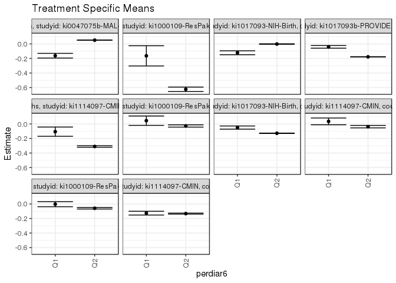

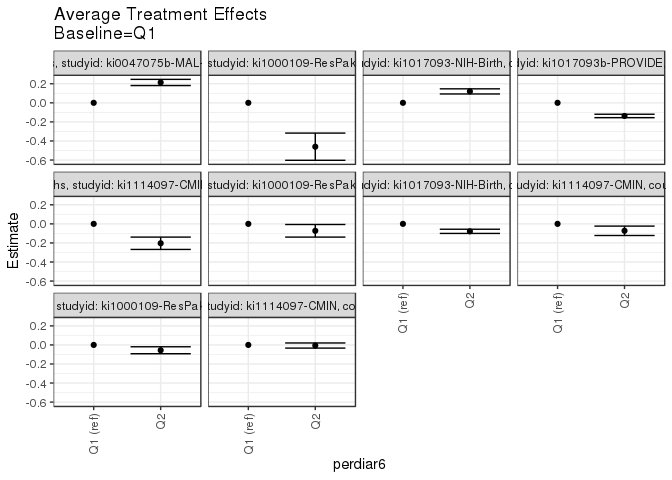

## Results Table

### Parameter: TSM

| agecat | studyid | country | intervention_level | baseline_level | estimate | ci_lower | ci_upper |
| --- | --- | --- | --- | --- | --- | --- | --- |
| 0-3 months | ki0047075b-MAL-ED | PERU | Q1 | NA | -0.1620535 | -0.1943607 | -0.1297463 |
| 0-3 months | ki0047075b-MAL-ED | PERU | Q2 | NA | 0.0517634 | 0.0503450 | 0.0531818 |
| 0-3 months | ki1000109-ResPak | PAKISTAN | Q1 | NA | -0.1639819 | -0.3032734 | -0.0246903 |
| 0-3 months | ki1000109-ResPak | PAKISTAN | Q2 | NA | -0.6244000 | -0.6553948 | -0.5934051 |
| 0-3 months | ki1017093-NIH-Birth | BANGLADESH | Q1 | NA | -0.1216578 | -0.1483898 | -0.0949257 |
| 0-3 months | ki1017093-NIH-Birth | BANGLADESH | Q2 | NA | -0.0017951 | -0.0049153 | 0.0013251 |
| 0-3 months | ki1017093b-PROVIDE | BANGLADESH | Q1 | NA | -0.0402285 | -0.0582445 | -0.0222125 |
| 0-3 months | ki1017093b-PROVIDE | BANGLADESH | Q2 | NA | -0.1779077 | -0.1799119 | -0.1759034 |
| 0-3 months | ki1114097-CMIN | PERU | Q1 | NA | -0.1063979 | -0.1700782 | -0.0427175 |
| 0-3 months | ki1114097-CMIN | PERU | Q2 | NA | -0.3098520 | -0.3205929 | -0.2991112 |
| 3-6 months | ki1000109-ResPak | PAKISTAN | Q1 | NA | 0.0448338 | -0.0195959 | 0.1092635 |
| 3-6 months | ki1000109-ResPak | PAKISTAN | Q2 | NA | -0.0278216 | -0.0433898 | -0.0122535 |
| 3-6 months | ki1017093-NIH-Birth | BANGLADESH | Q1 | NA | -0.0498514 | -0.0717965 | -0.0279063 |
| 3-6 months | ki1017093-NIH-Birth | BANGLADESH | Q2 | NA | -0.1282466 | -0.1308201 | -0.1256732 |
| 3-6 months | ki1114097-CMIN | GUINEA-BISSAU | Q1 | NA | 0.0350634 | -0.0113544 | 0.0814811 |
| 3-6 months | ki1114097-CMIN | GUINEA-BISSAU | Q2 | NA | -0.0374287 | -0.0542383 | -0.0206191 |
| 6-12 months | ki1000109-ResPak | PAKISTAN | Q1 | NA | -0.0034325 | -0.0382200 | 0.0313550 |
| 6-12 months | ki1000109-ResPak | PAKISTAN | Q2 | NA | -0.0593351 | -0.0700267 | -0.0486435 |
| 6-12 months | ki1114097-CMIN | GUINEA-BISSAU | Q1 | NA | -0.1264610 | -0.1522940 | -0.1006280 |
| 6-12 months | ki1114097-CMIN | GUINEA-BISSAU | Q2 | NA | -0.1327512 | -0.1399143 | -0.1255880 |

### Parameter: E(Y)

| agecat | studyid | country | intervention_level | baseline_level | estimate | ci_lower | ci_upper |
| --- | --- | --- | --- | --- | --- | --- | --- |
| 0-3 months | ki0047075b-MAL-ED | PERU | NA | NA | -0.1581085 | -0.1906285 | -0.1255886 |
| 0-3 months | ki1000109-ResPak | PAKISTAN | NA | NA | -0.1934958 | -0.3384003 | -0.0485914 |
| 0-3 months | ki1017093-NIH-Birth | BANGLADESH | NA | NA | -0.1191165 | -0.1460676 | -0.0921654 |
| 0-3 months | ki1017093b-PROVIDE | BANGLADESH | NA | NA | -0.0413143 | -0.0594662 | -0.0231624 |
| 0-3 months | ki1114097-CMIN | PERU | NA | NA | -0.1173363 | -0.1825933 | -0.0520792 |
| 3-6 months | ki1000109-ResPak | PAKISTAN | NA | NA | 0.0387792 | -0.0275800 | 0.1051384 |
| 3-6 months | ki1017093-NIH-Birth | BANGLADESH | NA | NA | -0.0509007 | -0.0730097 | -0.0287917 |
| 3-6 months | ki1114097-CMIN | GUINEA-BISSAU | NA | NA | 0.0319654 | -0.0174743 | 0.0814052 |
| 6-12 months | ki1000109-ResPak | PAKISTAN | NA | NA | -0.0070783 | -0.0435451 | 0.0293884 |
| 6-12 months | ki1114097-CMIN | GUINEA-BISSAU | NA | NA | -0.1267385 | -0.1535471 | -0.0999299 |

### Parameter: ATE

| agecat | studyid | country | intervention_level | baseline_level | estimate | ci_lower | ci_upper |
| --- | --- | --- | --- | --- | --- | --- | --- |
| 0-3 months | ki0047075b-MAL-ED | PERU | Q1 | Q1 | 0.0000000 | 0.0000000 | 0.0000000 |
| 0-3 months | ki0047075b-MAL-ED | PERU | Q2 | Q1 | 0.2138169 | 0.1814786 | 0.2461553 |
| 0-3 months | ki1000109-ResPak | PAKISTAN | Q1 | Q1 | 0.0000000 | 0.0000000 | 0.0000000 |
| 0-3 months | ki1000109-ResPak | PAKISTAN | Q2 | Q1 | -0.4604181 | -0.6031165 | -0.3177197 |
| 0-3 months | ki1017093-NIH-Birth | BANGLADESH | Q1 | Q1 | 0.0000000 | 0.0000000 | 0.0000000 |
| 0-3 months | ki1017093-NIH-Birth | BANGLADESH | Q2 | Q1 | 0.1198627 | 0.0929492 | 0.1467762 |
| 0-3 months | ki1017093b-PROVIDE | BANGLADESH | Q1 | Q1 | 0.0000000 | 0.0000000 | 0.0000000 |
| 0-3 months | ki1017093b-PROVIDE | BANGLADESH | Q2 | Q1 | -0.1376792 | -0.1558063 | -0.1195521 |
| 0-3 months | ki1114097-CMIN | PERU | Q1 | Q1 | 0.0000000 | 0.0000000 | 0.0000000 |
| 0-3 months | ki1114097-CMIN | PERU | Q2 | Q1 | -0.2034542 | -0.2680340 | -0.1388744 |
| 3-6 months | ki1000109-ResPak | PAKISTAN | Q1 | Q1 | 0.0000000 | 0.0000000 | 0.0000000 |
| 3-6 months | ki1000109-ResPak | PAKISTAN | Q2 | Q1 | -0.0726554 | -0.1389393 | -0.0063715 |
| 3-6 months | ki1017093-NIH-Birth | BANGLADESH | Q1 | Q1 | 0.0000000 | 0.0000000 | 0.0000000 |
| 3-6 months | ki1017093-NIH-Birth | BANGLADESH | Q2 | Q1 | -0.0783952 | -0.1004907 | -0.0562997 |
| 3-6 months | ki1114097-CMIN | GUINEA-BISSAU | Q1 | Q1 | 0.0000000 | 0.0000000 | 0.0000000 |
| 3-6 months | ki1114097-CMIN | GUINEA-BISSAU | Q2 | Q1 | -0.0724920 | -0.1218597 | -0.0231243 |
| 6-12 months | ki1000109-ResPak | PAKISTAN | Q1 | Q1 | 0.0000000 | 0.0000000 | 0.0000000 |
| 6-12 months | ki1000109-ResPak | PAKISTAN | Q2 | Q1 | -0.0559026 | -0.0922960 | -0.0195092 |
| 6-12 months | ki1114097-CMIN | GUINEA-BISSAU | Q1 | Q1 | 0.0000000 | 0.0000000 | 0.0000000 |
| 6-12 months | ki1114097-CMIN | GUINEA-BISSAU | Q2 | Q1 | -0.0062902 | -0.0330979 | 0.0205175 |